# Tween

# Tween animates things procedurally

With the `Tween` node, you can animate the properties of any node from code.

`Tween` nodes shine when you don’t know the start and end points of your animation in advance.

You give them any start and end values, and the engine takes care of playing the animation on the fly.

We call that process *interpolation*: the engine calculates new intermediate values every frame to smoothly animate a node’s property.

In this guide, you will learn:

- How to set up `Tween` nodes and use their key methods and signals.
- Animate movement between variable points.
- Animate with changing sizes.
- Animate multiple properties at the same time.
- Animate more complex changes with `interpolate_method()`.
- Queue animations using `yield()` and the `tween_all_completed` signal.

Contents:

- Setting up a Tween
- Tween’s key features
  - Animating one or more properties
  - Controlling the animation’s pace with easings
  - Knowing when an animation finished with its signals
  - Controlling playback
- How to use a Tween in practice
  - Moving to a target position
  - Animating with changing sizes
  - Animating multiple properties at once with a method
  - Sequencing animations
  - Tweening in 3D
  - Animating collectibles to UI elements
  - Smoothly animating a hand of cards
- Your questions
  - How can I tween movement at a constant speed?
  - How can I add custom easings?
  - How can I figure out property names?
  - When should I use an AnimationPlayer or a Tween?

## Setting up a Tween

There are three steps to animating properties with a `Tween` node:

1. Add a `Tween` node to your scene.
2. Prepare the animation by calling `interpolate_property()` or `interpolate_method()` one or more times.
3. Start the tween animation.

## Tween’s key features

### Animating one or more properties

The `Tween` node’s most commonly used method, `interpolate_property()`, has many parameters to control animation.

The first five are mandatory:

1. `object` is a reference to the node you want to animate.
2. `property` is the name of the property you want to animate, as a string. For example, write `"position"` to animate a node’s position.
3. `initial_val`: this is the starting value the `property` takes when you start the animation.
4. `final_val`: this is the final value you want the `property` to reach at the end of the animation.
5. `duration`: how long the animation should last.

The remaining three arguments are optional. They control the rhythm and spacing of the animation, that is, how the animated `property` changes over time:

1. `trans_type`: controls the easing equation the `Tween` node applies to this animation. You set it to a constant from the `Tween` class, like `Tween.TRANS_ELASTIC`.
2. `ease_type`: determines whether the animation should be faster at the start or the end of the transition. It’s also a constant from the `Tween` class. For example: `Tween.EASE_OUT`.
3. `delay`: you can optionally delay the start of the animation. This is useful when sequencing multiple animations, like when you animate multiple buttons appearing one after the other.

The `Tween` only begins interpolating the properties you set up once you call its `start()` method.

You can call `interpolate_property()` multiple times before calling `start()` to play multiple animations in parallel or in sequence.

While a tween is running, you can animate more properties by calling `interpolate_property()` and `start()` again. Doing so doesn’t affect active animations.

```
# Animates the circle growing from a scale of zero to one over one second.
$Tween.interpolate_property(
    $Circle, "scale", Vector2.ZERO, Vector2.ONE, 1.0
)
# Animates the circle fading it over one second.
$Tween.interpolate_property(
    $Circle, "modulate", Color.white, Color.transparent, 1.0
)
# When we start the $Tween, both animations run at the same time.
$Tween.start()
```

### Controlling the animation’s pace with easings

By default, `Tween` nodes use *linear interpolation*, which gives your animation a constant speed.

This kind of motion is rare in the real world, so it often looks unnatural. Other *easings* and *transition types* let us easily change the spacing of our animations (how the values changes over time).

`Tween` nodes offer two options to control the animation’s spacing. You use the `trans_type` and `ease_type` optional arguments when calling `interpolate_property()` or `interpolate_method()`.

As you write the function call, Godot auto-completes easing equations and types, showing you the available options.

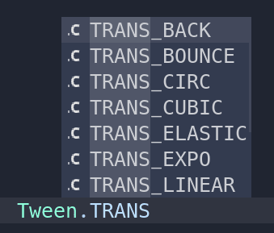

You can preview how all easings work and learn more about them on [easings.net](https://easings.net/), a handy free tool.

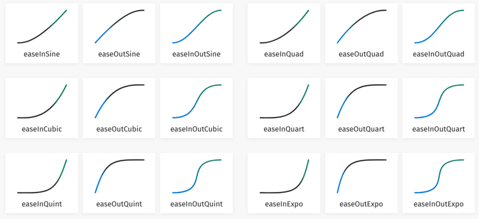

`Tween` nodes offer eleven easing equations to choose from. Here are some of the most common ones:

- `TRANS_LINEAR`: this is the default value for the `trans_type` argument. It makes the animation speed constant.
- `TRANS_QUAD`: the animation has a slight change of pace. It can accelerate and decelerate depending on the easing type you pick. More on that below.
- `TRANS_ELASTIC`: the animation wiggles around the start or end, which is great for spring motions or to give a sense of energy.
- `TRANS_BACK`: The animation overshoots and settles back down.

You combine the transition type with one of the four easing types to define the motion:

- `EASE_IN`: the animation starts slowly and speeds up towards the end.
- `EASE_OUT`: the animation starts quickly and slows down towards the end.
- `EASE_IN_OUT`: the animation is slowest at both ends and faster in the middle.
- `EASE_OUT_IN`: the animation is fastest at both ends and slower in the middle.

### Knowing when an animation finished with its signals

To react when an animation ends, the `Tween` provides valuable signals.

To trigger an action when all `Tween` animations finish, you can use the `tween_all_completed` signal.

However, if you want to detect when a specific node or property finished animating, you want to connect to the `tween_completed` signal.

This signal comes with two parameters:

1. The `object` is a reference to the node the `Tween` targeted.
2. The `key` is a text string representing the path to the animated property.

### Controlling playback

The `Tween` class has methods to start, stop, and step through the animation. You can also control the playback speed and create looping animations.

You can start and stop all interpolations with the `start()` and `stop()` functions respectively.

For every frame a `Tween` is animating, the node emits the `tween_step` signal for each animated node and property pair.

You can connect this signal to trigger events at key points during the animation.

To speed up or slow down all of your animations equally, you can alter the `Tween.playback_speed` property. It is a multiplier for how quickly the Tween should animate.

For example, if you set `playback_speed` to `2.0`, all animations play twice as fast (or take half their duration).

To make your animation loop, set the `Tween.loop` property to `true`. This is useful for continuously moving elevators or platforms. When looping, the `Tween` node never emits the `tween_all_completed` signal, as the animation never ends.

## How to use a Tween in practice

Here are some concrete use cases for `Tween` nodes.

### Moving to a target position

This example shows how to move a node to a target position that’s not known in advance. We use one `Tween` node to animate the ship’s `global_position`.

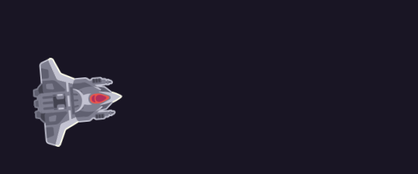

First, add a `Tween` node to the scene containing the node you want to move.

[figure not shown]

In a script attached to the root *Movement* node, we call the tween’s `interpolate_property()`.

```
onready var _ship := $ShipContainer
onready var _tween := $Tween


func move_ship_to_click(target_position: Vector2) -> void:
    # We turn the ship to look towards the target.
    _ship.look_at(target_position)
    _tween.interpolate_property(
        _ship, "global_position", _ship.global_position, target_position, 1.0
    )
    _tween.start()
```

### Animating with changing sizes

We can pass any value to the tween to create contextually sized animations.

Here we add a `Tween` and an `HSlider` to a scene. You can use that slider’s `value` property to determine how large an explosion animation should be.

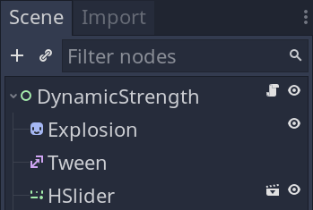

We can create a `Vector2` of our target scale using `Vector2.ONE * _slider.value`. This creates a `Vector2` with its `x` and `y` property set to `_slider.value`.

```
onready var _explosion := $Explosion
onready var _tween := $Tween
onready var _slider := $HSlider

var duration: float = 1.0


func _on_ExplodeButton_pressed() -> void:
    _explosion.rotation = rand_range(0, TAU)
    _tween.interpolate_property(
        _explosion, "scale", Vector2.ZERO, Vector2.ONE * _slider.value, duration
    )
    _tween.interpolate_property(_explosion, "modulate", Color.white, Color.transparent, duration)
    _tween.start()
```

### Animating multiple properties at once with a method

Instead of animating individual properties, a `Tween` can repeatedly call a function with the interpolated value as a parameter.

It allows you to:

- Animate multiple related properties with less code than using the `interpolate_property()` function.
- Use custom math formulas to control the animation. For example, you could use the `sin()` function to animate in wave-like patterns.
- Animate values you can’t directly interpolate with `Tween`, like colors.

Two buttons allow you to heal or damage the character, updating the bar.

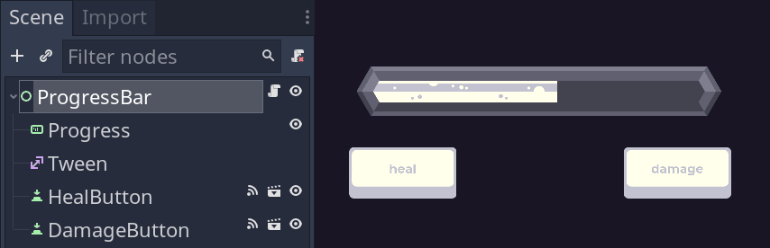

Once again, the root *ProgressBar* node has a script to access child nodes.

```
## This property keeps track of the current health, and its setter triggers the
## tween animation.
var health := 50 setget set_health

onready var _bar: TextureProgress = $Bar
onready var _tween: Tween = $Tween


func set_health(value: int) -> void:
    # We limit the `health` within the bar's value range.
    health = int(clamp(value, _bar.min_value, _bar.max_value))
    # Here, notice we call `interpolate_method()`. We have the `Tween` node
    # repeatedly call the `_update_health_bar()` method on this node.
    _tween.interpolate_method(self, "_update_health_bar", _bar.value, health, 0.33)
    _tween.start()


func _update_health_bar(health_target: float) -> void:
    _bar.value = health_target
    # We couldn't directly tween the color with `Tween.interpolate_property()`,
    # this is a case where we need to use `interpolate_method()` instead.
    _bar.tint_progress = Color("EB564B").linear_interpolate(
        Color("4DA6FF"), health_target / _bar.max_value
    )
```

### Sequencing animations

We can leverage a `Tween`’s signals to sequence animations in a loop.

In a loop, you can start an animation, then wait for it to finish using `yield()`.

You need to provide the `Tween` as the first parameter and `tween_all_completed` as the second. `tween_all_completed` is the signal emitted when all animations finished.

Then, the loop can continue to the next object to animate.

[output not shown]

Alternatively, we can use `interpolate_property()`’s last argument to delay animations.

Before the loop, define how long you want the delay between tweens to be, then keep a counter variable as you step through the loop. For each iteration, add one to your counter. Then, when you interpolate your property, multiply the counter by your delay time.

Once the loop finishes and the `Tween` starts, the animations start sequentially after the delay time.

```
# Delay to apply between animations in seconds.
const DELAY := 0.33
#...

func animate_rectangles_appearing_with_delay() -> void:
    #...
    var counter := 0
    for box in box_list:
        # The animation is the same as before, but notice how we use an extra
        # argument to delay each animation.
        # Also, we do not use a `yield()`.
        _tween.interpolate_property(
            box, "rect_rotation", -30, 0, 1.0, Tween.TRANS_ELASTIC, Tween.EASE_OUT, counter * DELAY
        )
        counter += 1
    _tween.start()
```

### Tweening in 3D

`Tween` nodes also work in 3D! We take advantage of the bounce easing to animate a spring in 3D.

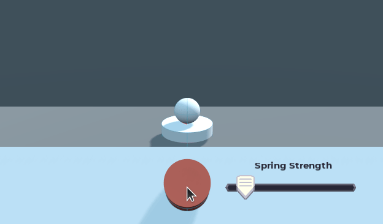

The spring has two parts to it:

- The top platform.
- The body of the spring.

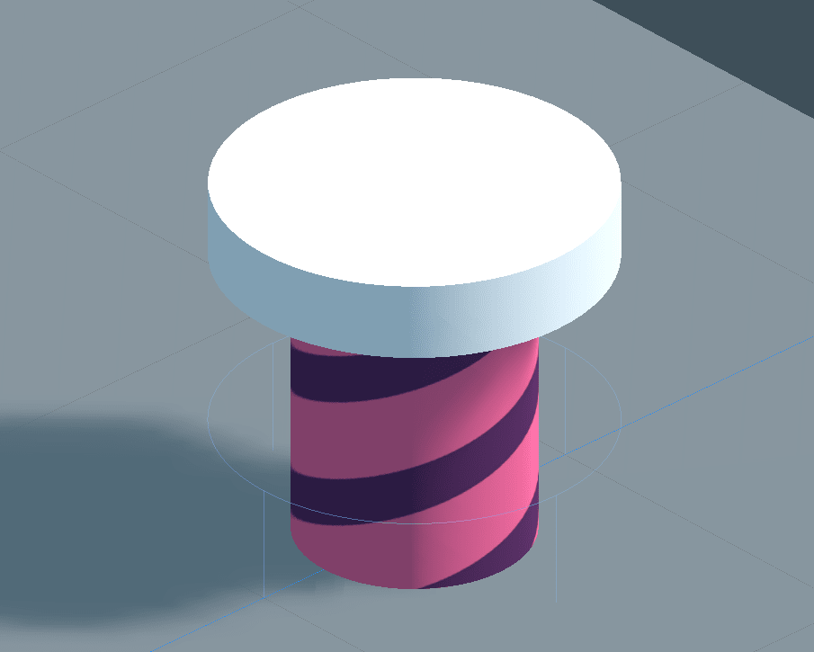

We animate these parts independently with a single `Tween`. First, we tween the translation of the top mesh in a dedicated function. We named it `bounce()`

```
var reset_delay := 0.3
var animation_time := 0.4
var reset_animation_time := 0.6

onready var _top: MeshInstance = $Top
onready var _body: Spatial = $Body
onready var _tween: Tween = $Tween


func bounce(strength: float) -> void:
    # We animate the top and reset its position after a delay
    _tween.interpolate_property(
        _top,
        "translation",
        _top.translation,
        Vector3(0, strength, 0),
        animation_time,
        Tween.TRANS_BOUNCE,
        Tween.EASE_OUT
    )
```

Continuing with the `bounce()` function, we use a second tween with a delay to move the top part back down after a few moments.

```
    _tween.interpolate_property(
        _top,
        "translation",
        Vector3(0, strength, 0),
        Vector3(0, 0.2, 0),
        reset_animation_time,
        Tween.TRANS_BACK,
        Tween.EASE_IN_OUT,
        # Notice we use the `delay` argument to play this animation after the
        # spring popped up.
        animation_time + reset_delay
    )
```

We also tween the scale of the body to stretch out the spring mesh. That way, it follows the platform.

```
    # Animate the spring body and reset its scale after a delay
    _tween.interpolate_property(
        _body,
        "scale",
        _body.scale,
        Vector3(1, strength, 1),
        animation_time,
        Tween.TRANS_BOUNCE,
        Tween.EASE_OUT
    )
    _tween.interpolate_property(
        _body,
        "scale",
        Vector3(1, strength, 1),
        Vector3(1, 0.2, 1),
        reset_animation_time,
        Tween.TRANS_BACK,
        Tween.EASE_IN_OUT,
        animation_time + reset_delay
    )

    _tween.start()
```

Using the `delay` property of `Tween`’s methods, we can queue or set up many animations in a single function and get great results.

### Animating collectibles to UI elements

We can animate collectible objects moving from the 3D world to the user interface using a `Tween`.

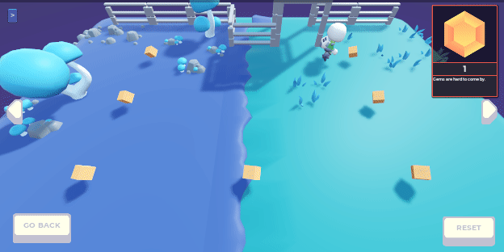

This makes it clear what the player has collected by visually linking them to a UI element.

In our demo, a *GemMover3D* node is in charge of animating the gems in the scene.

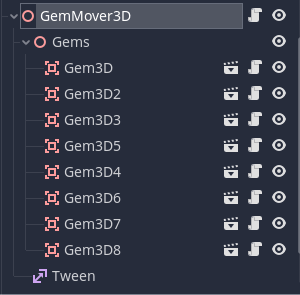

First, we cache the nodes we need, including the `Tween` node.

```
## Duration of the gem moving animation in seconds.
export var animation_time := 0.8
## Path to the UI node our 3D gems will animate to.
export(NodePath) var target_path
## Path to the camera node.
export(NodePath) var camera_path

onready var _target = get_node(target_path)
onready var _camera: Camera = get_node(camera_path)
onready var _gems: Spatial = $Gems
onready var _tween: Tween = $Tween
```

We emit a signal from each *Gem* when the player touches it. We connect this to our *GemMover3D* node in the `_ready()` function.

```
func _ready() -> void:
    for gem in _gems.get_children():
        gem.connect("collected", self, "_move_gem")
```

To calculate the end translation of the animation, we need two things:

- A reference to the UI element we want the gems to animate to.
- The current camera to project the UI elements position into the 3D world.

We use the cameras `project_position()` method to convert the UI’s 2D coordinates into a point in the 3D world. That’s where the gem moves.

```
func _move_gem(gem: Gem) -> void:
    _tween.interpolate_property(
        gem,
        "translation",
        gem.translation,
        _camera.project_position(_target.position, 1.0),
        animation_time,
        Tween.TRANS_EXPO,
        Tween.EASE_OUT
    )
    # Shrink the gems as they move towards the camera else they'll take up too
    # much of the screen.
    _tween.interpolate_property(
        gem, "scale", gem.scale, Vector3.ZERO, animation_time, Tween.TRANS_LINEAR, Tween.EASE_IN
    )
    _tween.start()
```

The `Camera.project_position()` method is a great tool to code interactions between the 3D world and the user interface.

### Smoothly animating a hand of cards

The `Tween` node is the tool of choice for all the animations you see in card games like *Hearthstone* or *Magic: The Gathering Arena*.

[figure not shown]

*Game: Magic: The Gathering Arena (2019)*

In the *CardDraw3D* example, we animate all cards in the player’s hand using a single `Tween` node.

[figure not shown]

For this example, we map the cards to a point on a curve based on its position in the hand.

We want to fan the cards on a nice curve and need a handful of properties to do so:

- We use two `Curve` resources to control the forward offset and rotation of each card.
- The `CARD_ROTATION` and `HAND_SPREAD` control the maximum angle and width of the hand of cards.
- We use the `HEIGHT_DIFFERENCE` to offset the cards towards the camera and avoid Z-fighting.

```
## Maximum rotation we apply to cards on the edges of the hand.
const CARD_ROTATION := deg2rad(15.0)
## Horizontal spread of the hands on the Z axis.
const HAND_SPREAD := 5.0
## Offset applied to each card towards the camera to render them in the correct
## order.
const HEIGHT_DIFFERENCE := 0.02

export var minimum_hand_size := 2
export var maximum_hand_size := 6
# We place cards along this curve.
export var height_curve: Curve
# This curve controls the amount of rotation applied to each card.
export var rotation_curve: Curve

onready var _cards: Spatial = $Cards
onready var _tween: Tween = $Tween
```

Once more, we use one function to tween the cards: `_align_cards()`.

Every time we add or remove a card to the hand, we call this function. It loops over every card, calculates a new target transform, and tweens to it.

```
func _align_cards() -> void:
    var adjusted_card_count := _cards.get_child_count() - 1
    for child_index in _cards.get_child_count():
        # We use this line to get type checks and autocompletion in the editor.
        var card := _cards.get_child(child_index) as Card3D

        var ratio_in_hand := float(child_index) / adjusted_card_count
        var new_transform := _calculate_new_card_transform(child_index, adjusted_card_count, ratio_in_hand)

        _tween.interpolate_property(
            card, "transform", card.transform, new_transform, 1.2, Tween.TRANS_EXPO, Tween.EASE_OUT
        )
    _tween.start()
```

We calculate each card’s new transform in a dedicated function. This allows us to get nice animations with a single tween.

```
func _calculate_new_card_transform(index: int, count: int, ratio_in_hand: float) -> Transform:
    var new_translation := Vector3(
        # Due to our camera's rotation, the X axis moves the card forward.
        height_curve.interpolate(ratio_in_hand) * 2.0,
        # This line offsets each card up so it appears in front of the one
        # before it.
        index * HEIGHT_DIFFERENCE,
        # We spread cards horizontally on the screen using the Z axis.
        -(HAND_SPREAD * count * 0.5) + index * HAND_SPREAD
    )
    var new_angle := -PI / 2.0 + rotation_curve.interpolate(ratio_in_hand) * CARD_ROTATION
    # The basis is a group of three vectors representing the object's local
    # axes, giving us information about its orientation and scale.
    var new_rotation_and_scale := Basis(Vector3.UP, new_angle).scaled(Vector3.ONE * 2.0)
    # We can build a tranform from a basis and a translation to pack position,
    # rotation, and scale in a single value. That's handy for animation!
    return Transform(new_rotation_and_scale, new_translation)
```

The `Curve` resources have values ranging from `-1` to `1` which simplifies our code: we naturally get a nice fanning thanks to this.

## Your questions

### How can I tween movement at a constant speed?

You control `Tween` animations by giving them a set duration.

This means that an animation moving a few pixels across is much slower than an animation to the other side of the screen if they have the same duration.

To move at a constant speed with `Tween` nodes, you need to calculate the duration instead.

For example, if you want to move a sprite at a constant speed, you can calculate the duration using the function `speed = distance / time`.

We can rearrange this making time the subject: `time = distance / speed`.

We can define a desired speed and distance then set the animation duration to be `distance / speed`.

```
var speed := 50.0

var origin := Vector2(512, 512)
var target := Vector2(1024, 1024)

var distance := origin.distance_to(target)
var tween_duration := distance / speed
```

You can apply this approach to any animation by calculating `duration = amount_to_change / rate_of_change`.

### How can I add custom easings?

You can use `interpolate_method()` and a `Curve` resource to design a custom animation transition.

```
export (Curve) var curve: Resource = Curve.new()
```

The `Curve` resource appears in the *Inspector* and you can edit it interactively.

In code, to animate using the curve, first create a function to start a method with a linear tween from `0.0` to `1.0`.

```
onready var _tween := $Tween

func start_tween() -> void:
    _tween.interpolate_method(self, "interpolate_curve", 0.0, 1.0, 1.0)
    _tween.start()
```

Then, we can create the `interpolate_curve()` and call `Curve.interpolate()` to apply our custom transition.

Finally, we can use the `lerp()` method to turn our value between `0.0` and `1.0` into a value positioned between our starting value and ending value to use in an animation.

```
func interpolate_curve(value: float) -> void:
    # This gives you a value between 0 and 1 to your easing.
    var eased_value := curve.interpolate(value)
    # If you want to set this to be a value between a start and end value,
    # you can use it like this.
    var animation_value := lerp(start_value, end_value, eased_value)
```

### How can I figure out property names?

You can find the string name for a property in the editor by hovering over them. Their name appear in a tooltip.

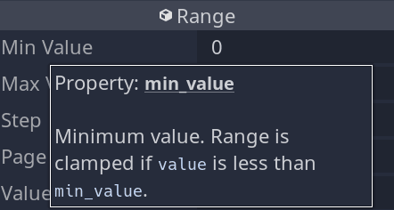

### When should I use an AnimationPlayer or a Tween?

You can often use either an `AnimationPlayer` or a `Tween`.

`Tween` nodes excel in three areas:

- `Tween` nodes’ start and end points can be calculated on the fly, such as moving to an unknown point or changing a number.
- Applying a similar animation to many components is straightforward with `Tween` nodes. You can create a function to reuse the same animation on different nodes.
- `Tween` nodes have predefined easings which make them quick to apply simple animations with a consistent aesthetic at the cost of being harder to fine-tune.

You can use `AnimationPlayer` in all other cases, and especially whenever your animation is static.